# CLB Business Licensing Trends Analysis

> “Anything on seasonal [business licensing] fluctuation? For instance, the licenses in the latter half of the year generally take longer because there is a lot of construction going on.”

We will be importing the latest Business Licensing dataset available from City of Long Beach / Financial management and first analyze trends for Active licenses. This analysis will include all licensing activity (new, issued, renewed).

Afterward, we will see if there is any time series trends for how many days it takes to issue a license to a new applicant.

## Methodology

As part of this analysis, a time series forecast was produced using the [Prophet library](https://facebookincubator.github.io/prophet/) and the process date of our active licenses. The forecast is based on an additive model where non-linear trends are fit with yearly seasonality. The forecasting model is robust to missing data, shifts in the trend, and large outliers. Forecasts were produced for newly entered license applications, issued licenses, and renewed licenses.

Code for this analysis project was written in the “R” programming language and was used to clean up business licensing data and to integrate/fit the model. Any savvy analyst or data scientist can reproduce the results from this notebook using the [following code published on GitHub](https://github.com/lxchavez/CLB-Business-Licensing-Trend-Analysis).

## Data Source

The forecasting model was fit with approximately 17.6k “Active” business licenses between August 2015 and February 2017. All licenses before August 2015 will be filtered out of this analysis due to the new version of the LMR/Hansen business licensing module coming online at this time. License milestones for new applications were not tracked electronically prior to this upgrade, meaning that we don’t have electronic log of some sort containing “first issued” dates.

Active business licenses are defined by Brett Yakus as those having a license status of:

- Active
- CollcInBus
- Expired (a licensee might become reactivated before going into collections)
- Pending
- Conditionl

Furthermore, active licenses have one of the following milestones:

- Issued
- Renewed
- Collections
- Pre-Collections
- Pre-Renew
- Renewed

In order to help create a summary of license activity, we can calculate how many days it takes to issue a license for an applicant by pulling in additional relational data. Business licensing milestones are comprised of a “log” recording change of status for each business license or application by date/time and inspector. The number of days it took to issue a business is calculated by subtracting the difference between the intake date and the issued date. Unfortunately, this calculation only works if we have the intake date in our milestones. Meaning that we won’t know the “days to issue” for business licenses that were in the system before August 2015.

### Assumptions

For the sake of this analysis and the need to get a high-level trend of licensing activity I decided not to exclude rentals or commercial licenses. Keep this in mind when comparing the number of active licenses from this analysis to other reports relating to business licensing that you might come across.

## Exploratory Data Analysis

How many “Intake”, “Issued”, and “Renewed” milestones do we have?

Number of licenses entered into the system (intake)

```r
active_license_milestone_summary %>%
  filter(!is.na(date_intake)) %>%
  count()
```

| n |
| --- |
| 2819 |

Number of licenses issued

```r
active_license_milestone_summary %>%
  filter(!is.na(date_issued)) %>%
  count()
```

| n |
| --- |
| 3624 |

Number of licenses renewed

```r
active_license_milestone_summary %>%
  filter(!is.na(date_renewed)) %>%
  count()
```

| n |
| --- |
| 14672 |

How many observations do we have a “Days to Issue” calculation for?

```r
active_license_milestone_summary %>%
  filter(!is.na(days_to_issue)) %>%
  nrow()
```

```
[1] 2818
```

### Outliers Analysis

What are the average and median days to issue?

```r
active_license_milestone_summary %>%
  filter(!is.na(days_to_issue)) %>%
  summarise(count = n(),
            mean = round(mean(days_to_issue), 1),
            median = round(median(days_to_issue), 1),
            std_dev = round(sd(days_to_issue), 1),
            min = min(days_to_issue),
            max = max(days_to_issue))
```

| count | mean | median | std_dev | min | max |
| --- | --- | --- | --- | --- | --- |
| 2818 | 26.4 | 1 | 55.6 | 0 | 482 |

```r
quantile(active_license_milestone_summary$days_to_issue, na.rm = TRUE)
```

```
    0%    25%    50%    75%   100%
  0.00   0.00   1.00  25.75 482.00
```

Let’s define our outliers as those whose “Days to Issue” metric are greater than the 3rd quantile.

```r
third_quantile <- quantile(active_license_milestone_summary$days_to_issue, probs = (0.75), na.rm = TRUE)
outliers <- active_license_milestone_summary %>%
  filter(days_to_issue > third_quantile)
```

```r
outliers %>%
  group_by(liccatdesc) %>%
  summarise(
    count = n()
  ) %>%
  arrange(desc(count))
```

| liccatdesc | count |
| --- | --- |
| Restaurant & Ready to Eat Foods | 79 |
| Retail Sales | 56 |
| Food Retail Store | 37 |
| Business Office | 32 |
| Barber/Beauty Shop Owner | 31 |
| Restaurant & Ready to Eat Foods with Alcohol | 27 |
| Medical Office/Clinic | 25 |
| Internet Sales/Service | 23 |
| Massage/Body Wrap Tech | 23 |
| Food Retail Store w/ Alcohol | 19 |

[output cut: 103 more lines]

Let’s see what milestone states the longest Days to Issue applicant went through to get their first license.

```r
max_outlier <- outliers %>%
  filter(days_to_issue == max(days_to_issue)) %>%
  select(licenseno)
# Get the license number
max_outlier_licenseno <- max_outlier$licenseno[[1]]
```

```r
outliers %>%
  filter(days_to_issue == max(days_to_issue)) %>%
  select(licenseno, dbaname, typeofbusiness, bid, homebased, classdesc, days_to_issue)
```

| licenseno | dbaname | typeofbusiness | bid | homebased | classdesc | days_to_issue |
| --- | --- | --- | --- | --- | --- | --- |
| BU21523945 | RECY'S BEAUTY SALON | Barber/Beauty Shop Owner | NA | No | Services | 482 |

```r
# Inspect milestones
milestones %>%
  filter(licenseno == max_outlier_licenseno)
```

| licenseno | addby | aplickey | statusdttm | code | load_date |
| --- | --- | --- | --- | --- | --- |
| BU21523945 | ASWIEGE | 21523945 | 2015-09-23 15:10:21 | Intake | 2017-03-02 01:00:35 |
| BU21523945 | ASWIEGE | 21523945 | 2015-09-23 15:11:18 | Planning Review | 2017-03-02 01:00:35 |
| BU21523945 | JOINIES | 21523945 | 2015-11-16 08:03:30 | Application Fees | 2017-03-02 01:00:40 |
| BU21523945 | JOINIES | 21523945 | 2015-11-16 08:03:30 | Department Reviews | 2017-03-02 01:00:40 |
| BU21523945 | COVANDE | 21523945 | 2016-12-28 09:04:26 | Taxes & Fees | 2017-03-02 01:01:55 |
| BU21523945 | WSiNovah | 21523945 | 2017-01-06 08:54:44 | Pending | 2017-03-02 01:01:58 |
| BU21523945 | NALOPEZ | 21523945 | 2017-01-17 11:15:13 | Issued | 2017-03-02 01:01:59 |

Unlike the barber shop owner, however, the majority of business licenses are issued within a day.

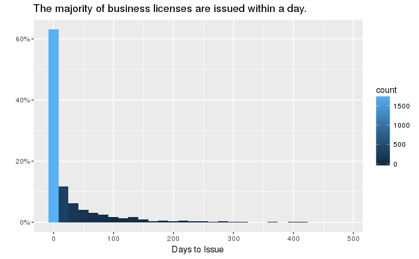

```r
active_license_milestone_summary %>%
  filter(!is.na(days_to_issue)) %>%
  ggplot(aes(x = days_to_issue, y = (..count..) / sum(..count..))) +
  geom_histogram(bins = 30, aes(fill = ..count..)) +
  scale_y_continuous(labels = scales::percent_format()) +
  labs(
    title = "The majority of business licenses are issued within a day.",
    x = "Days to Issue",
    y = ""
  )
```

### Forecasting Overall Licensing Activity

Let’s create a forecast to see overall licensing activity before we dive into more specific license milestone trends.

#### Get a daily count of Active/Issued licenses

Clean up steps executed to count our data:

1. Filters milesonedate to be in the range of our defined analysis date range.
2. Summarises the dataframe by counting the number of observations (y) grouped by the desired date.
3. Log-transforms the y variable for us to more clearly see increases in variation over time. This is especially important for exponentiall growing trends.
4. Renames our date/milestone date and count variable to **ds** and **y** respectively. The `prophet` library expects these named parameters to create our forecasting model.

```r
daily_count <- business_licenses %>%
  df_daily_count(business_licenses$milestonedate)
```

We are using the **milestonedate** in our analysis. The milestone date is used by Hansen as the log date/time stamp to capture capture events for a business licensee.

#### Create a forecasting model

We fit the model by passing in the historical dataframe and instantiating a new `Prophet` object. I have decided to not fit weekly seasonality as there was a lot of noise in our forecasted data.

```r
m <- prophet(daily_count, weekly.seasonality = FALSE)
```

[output not shown]

#### Predicting activity

Predictions are then made on a dataframe with a column named `ds` containing the dates for which predictions are to be made. The `make_future_dataframe` function takes the model object and a number of periods to forecast and produces a suitable dataframe. By default it will also include the historical dates so we can evaluate in-sample fit.

We will now make predictions with the model for the next year (or 365 periods) worth of all business licensing activity.

```r
future <- make_future_dataframe(m, periods = 365)
forecast <- predict(m, future)
```

The forecast can be visualized using the `plot` function.

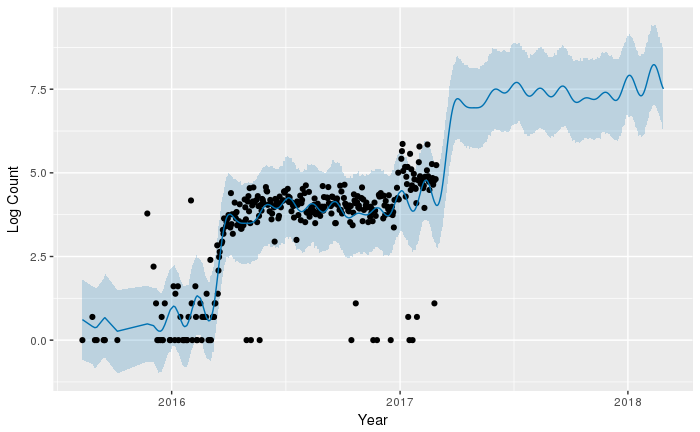

```r
plot_forecast(m,
              forecast,
              xlabel = 'Year',
              ylabel = "Log Count")
```

We can use the `prophet_plot_components` function to see the forecast components. By default you’ll see the trend, yearly, seasonality, and weekly seasonality of the time series.

It appears that there is more overall licensing activity during the spring and summer months.

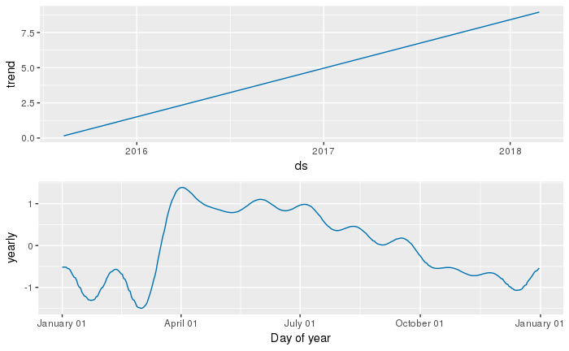

```r
prophet_plot_components(m, forecast)
```

# License Milestone Seasonality/Trends Analysis

So far we’ve explored time series seasonality for **ALL** business licensing activity. How about new/issued licenses? Renewed licenses?

## Days to Issue

```r
daily_count <- active_license_milestone_summary %>%
  mutate(ds = as_date(date_issued)) %>%
  filter(ds >= analysis_date_start & ds <= analysis_date_end & !is.na(days_to_issue)) %>%
  group_by(ds) %>%
  summarise(y = mean(days_to_issue)) %>%
  select(ds, y)
m <- prophet(daily_count, weekly.seasonality = FALSE)
```

[output not shown]

```r
future <- make_future_dataframe(m, periods = 365)
forecast <- predict(m, future)
```

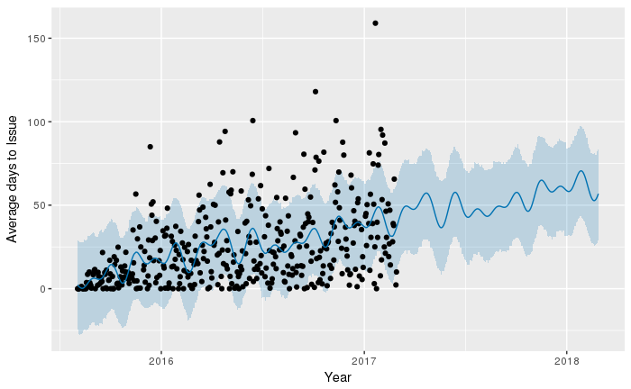

```r
plot_forecast(m,
              forecast,
              xlabel = 'Year',
              ylabel = "Average days to Issue")
```

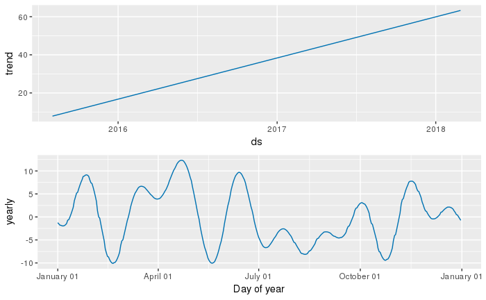

```r
prophet_plot_components(m, forecast)
```

### Interpretation

When examining the year-over-year trend, it appears that there are seasonal peaks in the process time at the beginning of the year, late spring and summer months. There also seems to be an upward trend on the number of days to issue business licenses. I believe this can be attributed to our sample size of business licenses and the unfortunate fact of not being able to track licenses to this detail prior to the last major Hansen upgrade.

Expect trends to start converging once we have an additional year or so worth of licensing applicant data.

## New License Applications (Intake) Trends

```r
daily_count <- active_license_milestone_summary %>%
  df_daily_count(active_license_milestone_summary$date_intake)
```

```r
m <- prophet(daily_count, weekly.seasonality = FALSE)
```

[output not shown]

```r
future <- make_future_dataframe(m, periods = 365)
forecast <- predict(m, future)
```

Create a summary dataframe to compare

```r
summary_df <- df_for_plotting(m, forecast) %>%
  mutate(license_subset = "Intake")
```

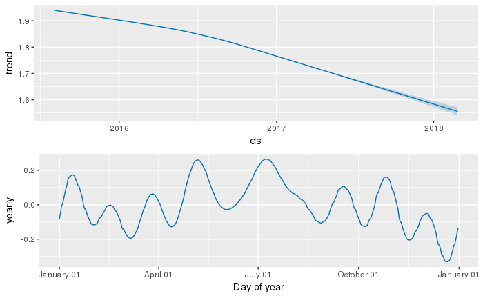

```r
prophet_plot_components(m, forecast)
```

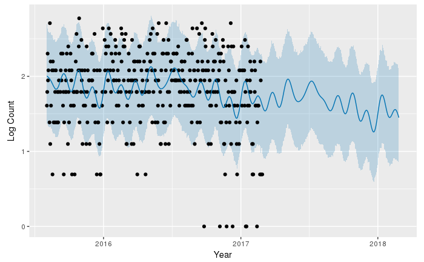

```r
plot_forecast(m,
              forecast,
              xlabel = 'Year',
              ylabel = "Log Count")
```

## Issued License Trends

```r
daily_count <- active_license_milestone_summary %>%
  df_daily_count(active_license_milestone_summary$date_issued)
```

```r
m <- prophet(daily_count, weekly.seasonality = FALSE)
```

[output not shown]

```r
future <- make_future_dataframe(m, periods = 365)
forecast <- predict(m, future)
```

Append to summary dataframe.

```r
plotting_df <- df_for_plotting(m, forecast) %>%
  mutate(license_subset = "Issued")
summary_df <- summary_df %>%
  bind_rows(plotting_df)
```

The number of issued licenses also seem to be (slightly) trending downward.

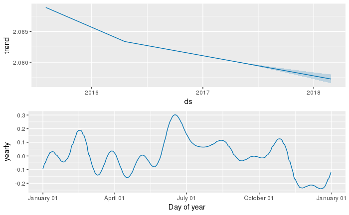

```r
prophet_plot_components(m, forecast)
```

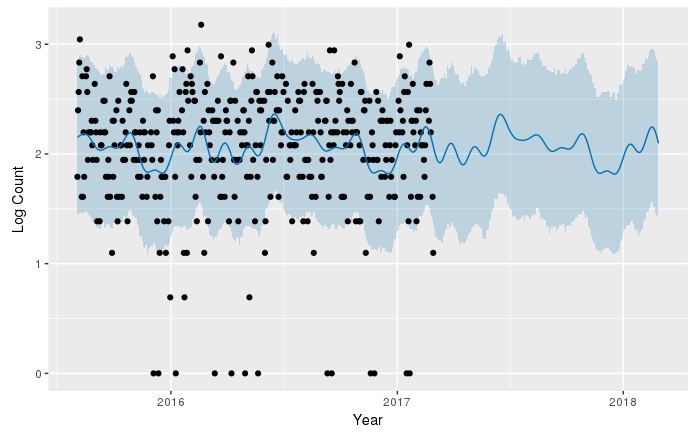

```r
plot_forecast(m,
              forecast,
              xlabel = 'Year',
              ylabel = "Log Count")
```

## Renewed Licenses

```r
daily_count <- active_license_milestone_summary %>%
  df_daily_count(active_license_milestone_summary$date_renewed)
```

```r
m <- prophet(daily_count, weekly.seasonality = FALSE)
```

[output not shown]

```r
future <- make_future_dataframe(m, periods = 365)
forecast <- predict(m, future)
```

Append to summary dataframe.

```r
plotting_df <- df_for_plotting(m, forecast) %>%
  mutate(license_subset = "Renewed")
summary_df <- summary_df %>%
  bind_rows(plotting_df)
```

The number of renewed licenses also seem to be trending downward.

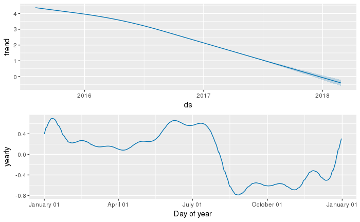

```r
prophet_plot_components(m, forecast)
```

The dip of license renewals might be attributed to the below chart. It appears that there was significantly more licensing renewal during the first-half of 2016 compared to the second-half. Therefore suggesting seasonality for license renewal in the first half (January and summer months) of the year.

It will be interesting to re-calculate these trends again in a few months to see where we stand in terms of licensing renewals.

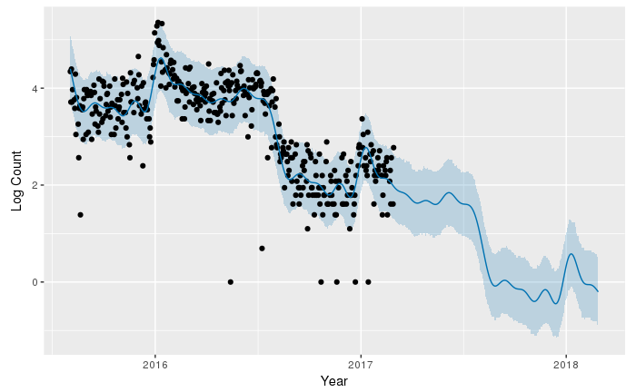

```r
plot_forecast(m,
              forecast,
              xlabel = 'Year',
              ylabel = "Log Count")
```

## Summary

Business licensing activity during the year peaks at the beginning of the year and during summer months. This finding is consistent with Brett’s anecdote of his department being the busiest during the summer.

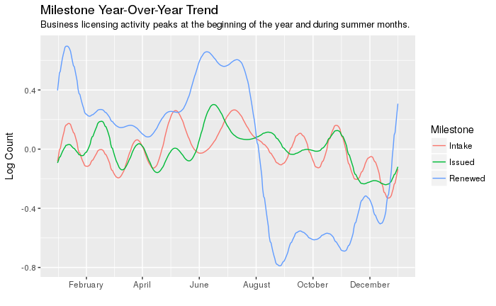

It’s also worth noting there decreased activity around license renewals from during the fall months and picks up again towards January. New applications and issued licensing activity are mostly consistent throughout the year and dip towards the end of the year – this activity might reflect the holidays, people and staff taking time off, and so on.